# `resid_plot`Calculate residual values and create plots

#### Description

Function for creating plots and tables for residual values from observed and estimated values. #### Usage

```
resid_plot(df, obs, ..., type = "scatterplot", point_size = 3,
color = NA, nrow = NA, ncol = NA, lim_y = NA,
xlab = "Observed values", clab = NA, font = "serif",
legend_pos = "bottom", gray_scale = TRUE, res_table = FALSE)
```

#### Arguments

- `df`: A data frame.
- `obs`: Quoted name of the observed values variable.
- `...`: Quoted name(s) for the estimated values variable(s). Multiple variables must be separated by comma.
- type Character object for the type of plot created, The available plots are: “scatterplot”, “histogram”, “histogram_curve” and “versus”. Default: “scatterplot”.
- `point_size`: Numeric value for the point size in scatter plots. Default: 3.
- `color`: Quoted name of a variable. If supplied, this variable will be used to classify the data by color. Default: NA.
- `nrow`: Numeric value for number of rows in the plot matrix. If not supplied, the plots will be automatically sorted. Default: NA.
- `ncol`: Numeric value for number of columns in the plot matrix. If not supplied, the plots will be automatically sorted. Default: NA.
- lim_y Numeric value for the y axis upper and lower limit. If NA, the biggest residual value is used. Default: NA.
- `xlab`: Character value for the x label used in some plots. Default: “Observed values”.
- clab Character value for the color label used, if a color variable is supplied. If not supplied, the color variable name will be used. Default: NA.
- font Type of font used in the plot. Default: “serif”.
- `legend_pos`: Position of legend, when a color variable is supplied. This can either be “left”, “right”, “top” or “bottom”. Default: “bottom”.
- gray_scale If TRUE, the plot will be rendered in a gray scale. Default: “TRUE”.
- res_table If TRUE, the function will return a data frame with observed, estimated, and residual values. Default: FALSE.

#### Examples

```r
library(forestmangr)
data("exfm11")
head(exfm11)
```

```
##   STRATA PLOT   TH  TH_EST1  TH_EST2  TH_EST3
## 1      2    1 23.8 24.53415 23.78845 23.80454
## 2      2    1 23.8 23.16621 21.74226 21.86217
## 3      2    1 24.7 24.53415 23.78845 23.80454
## 4      2    1 23.3 23.53835 22.26417 22.38524
## 5      2    1 24.3 24.53415 23.78845 23.80454
## 6      2    1 22.4 23.88927 22.77895 22.88215
```

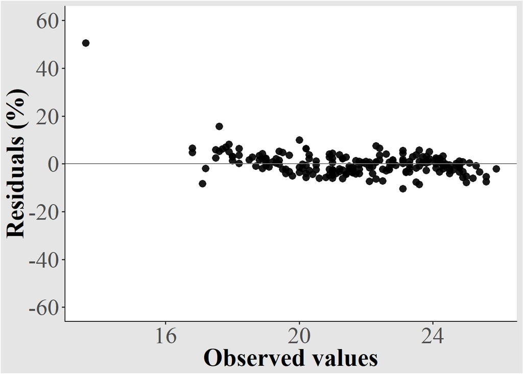

```r
# Specifying the observed and estimated variables, we get a scatter plot for the percentage residuals:
resid_plot(exfm11, "TH", "TH_EST1")
```

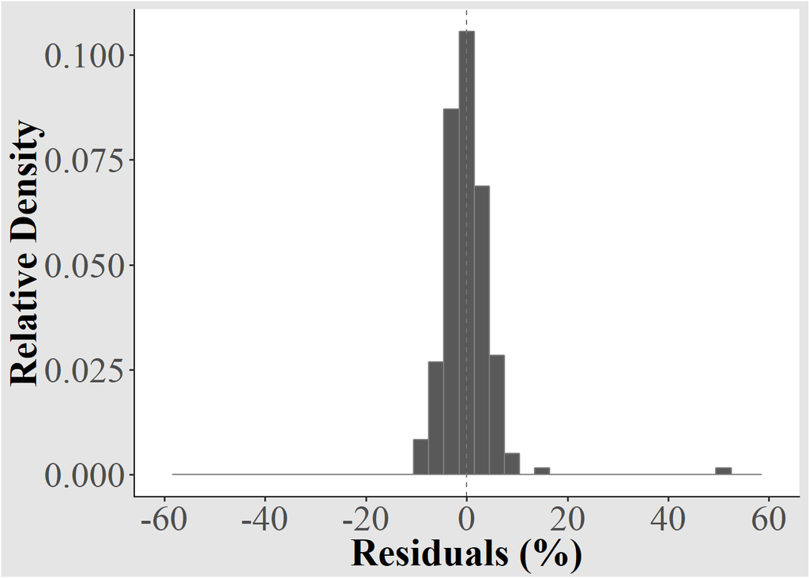

```r
# It's possible to get other types of plots, with the type argument:
resid_plot(exfm11, "TH", "TH_EST1", type = "histogram")
```

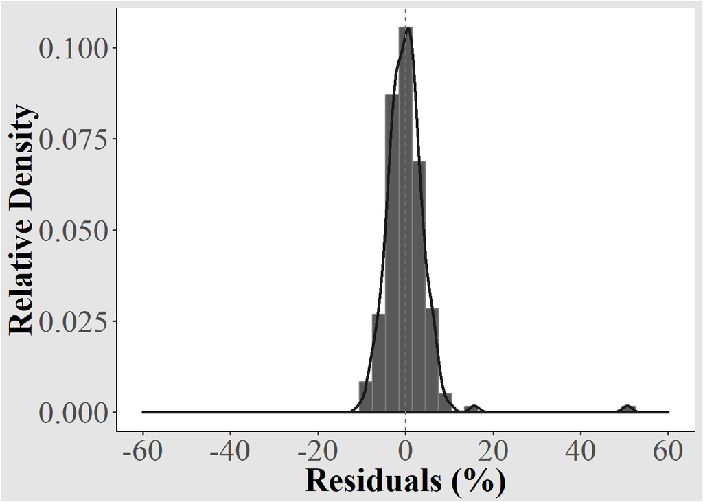

```r
resid_plot(exfm11, "TH", "TH_EST1", type = "histogram_curve")
```

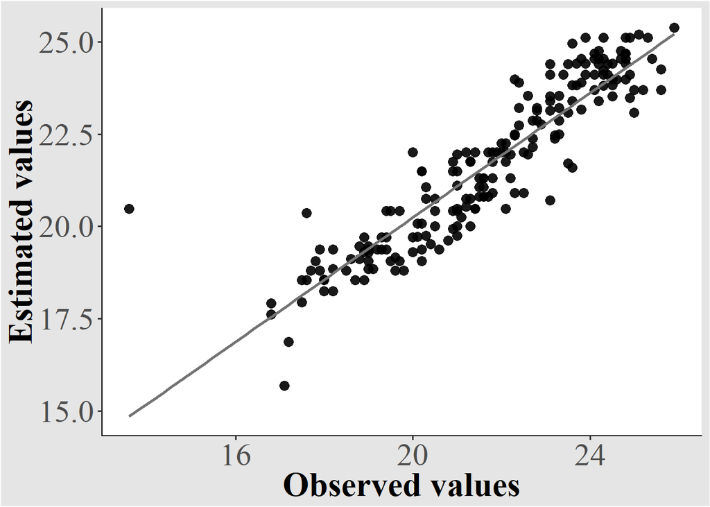

```r
resid_plot(exfm11, "TH", "TH_EST1", type = "versus")
```

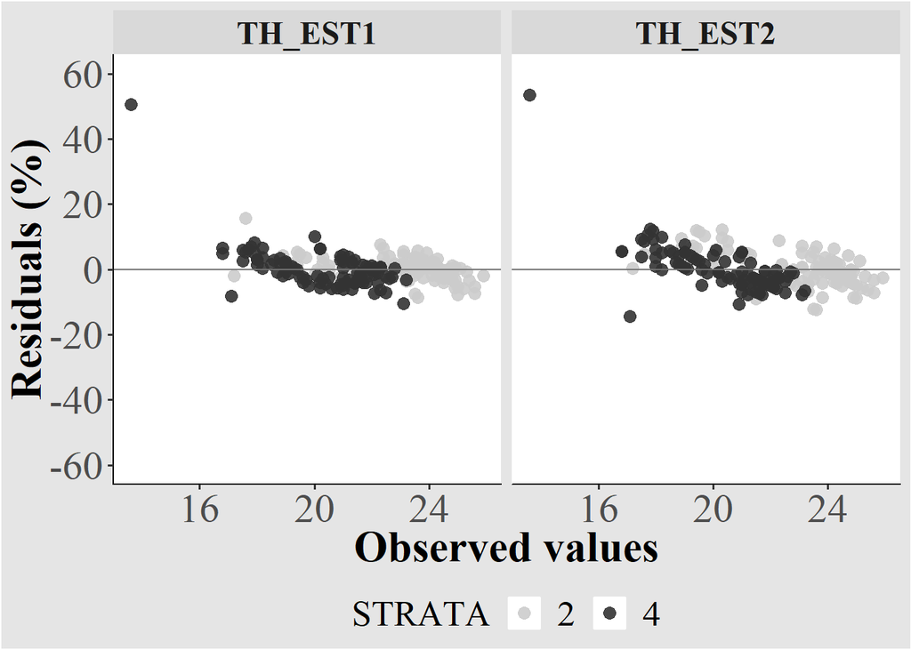

```r
# It's possible to add a factor variable as color in the plots:
resid_plot(exfm11, "TH", "TH_EST1", "TH_EST2", color="STRATA")
```

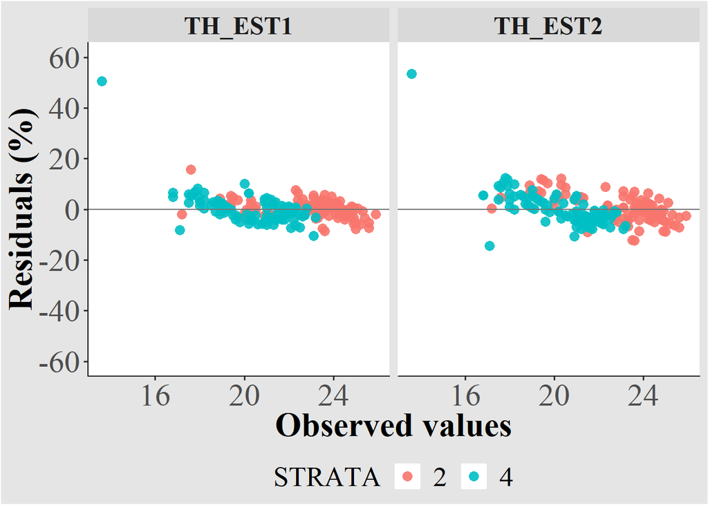

```r
# A colored plot is also available:
resid_plot(exfm11, "TH", "TH_EST1", "TH_EST2", color="STRATA", gray_scale=FALSE)
```

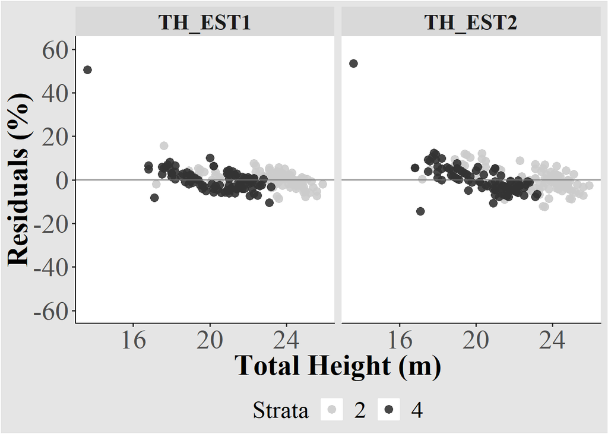

```r
# It's possible to change xlabels and color labels:
resid_plot(exfm11, "TH", "TH_EST1", "TH_EST2", color="STRATA", xlab="Total Height (m)", clab="Strata")
```

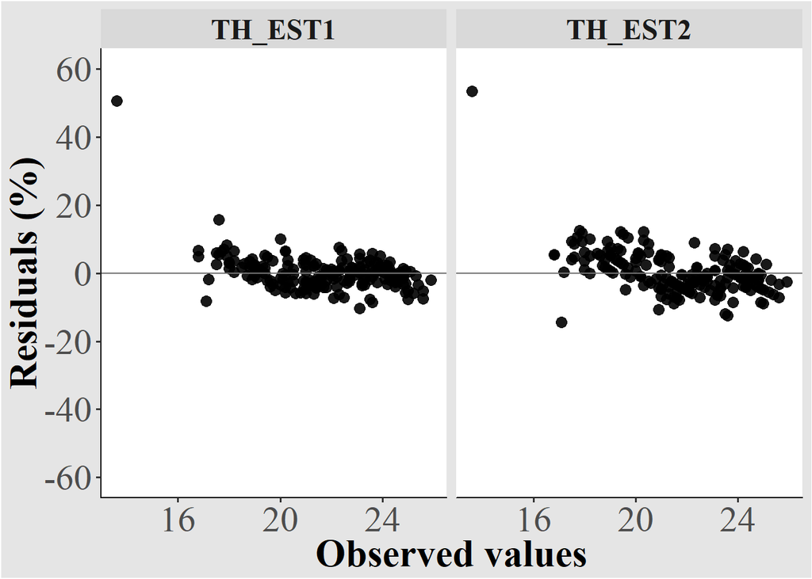

```r
# If there are more estimated values variables, they can also be used in the comparison:
resid_plot(exfm11, "TH", "TH_EST1", "TH_EST2")
```

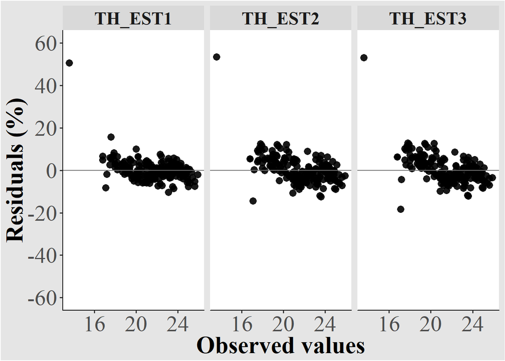

```r
resid_plot(exfm11, "TH", "TH_EST1", "TH_EST2", "TH_EST3")
```

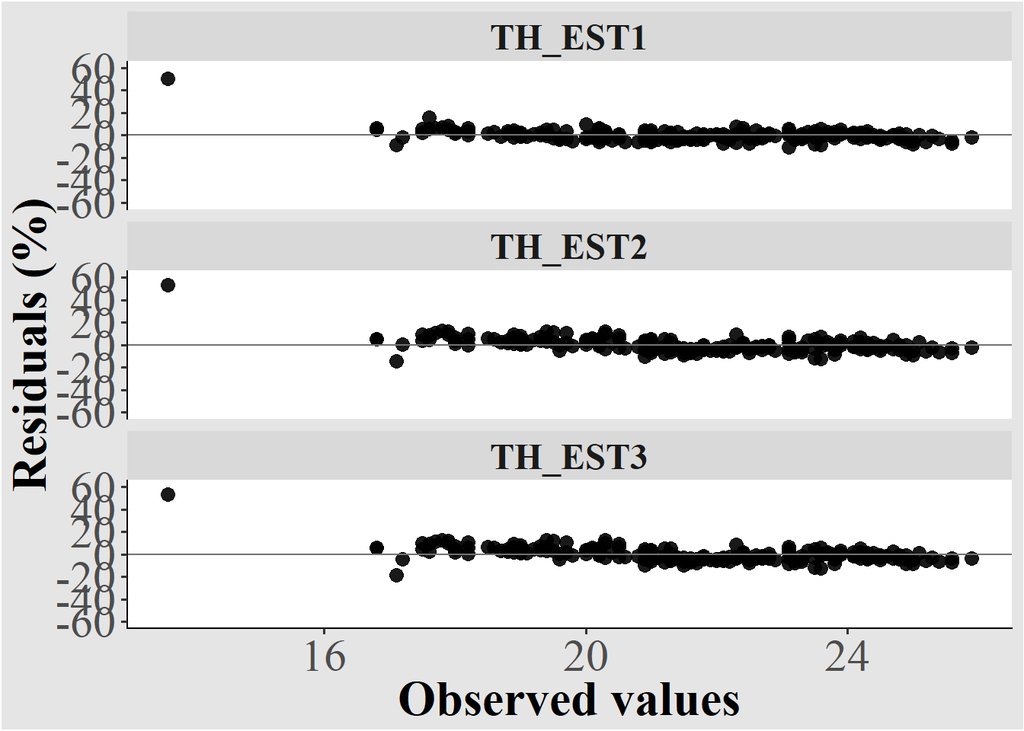

```r
# It's possible to rearrange the plots with ncol and nrow:
resid_plot(exfm11, "TH", "TH_EST1", "TH_EST2", "TH_EST3", ncol=1)
```

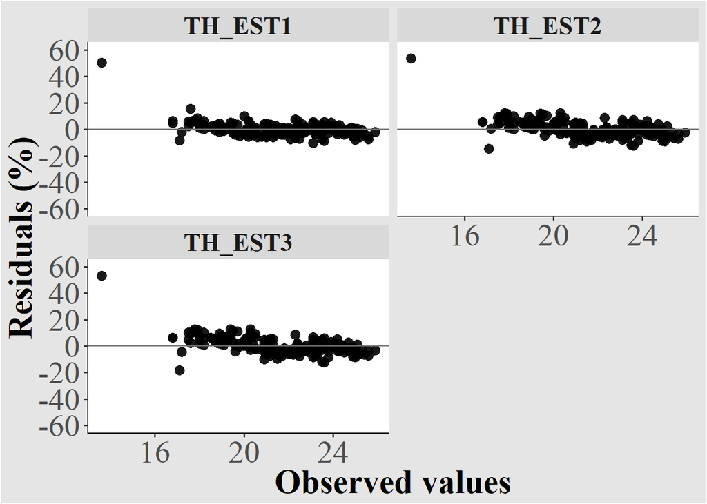

```r
resid_plot(exfm11, "TH", "TH_EST1", "TH_EST2", "TH_EST3", nrow=2)
```

```r
# It's possible to get the residuals table used to generate these plots, with res_table=TRUE:
head( resid_plot(exfm11, "TH", "TH_EST1", "TH_EST2", res_table = TRUE) )
```

```
##        ID   TH      EST      ERROR
## 1 TH_EST1 23.8 24.53415  3.0846727
## 2 TH_EST1 23.8 23.16621 -2.6630006
## 3 TH_EST1 24.7 24.53415 -0.6714490
## 4 TH_EST1 23.3 23.53835  1.0229720
## 5 TH_EST1 24.3 24.53415  0.9635889
## 6 TH_EST1 22.4 23.88927  6.6485183
```